# Project: Investigate a Dataset:TMDB Movie Data

- Introduction
- Data Wrangling
- Exploratory Data Analysis
- Conclusions

## Introduction

This data set contains information about 10,000 movies collected from The Movie Database (TMDb), including user ratings,popularity and revenue.It also provides information on cast,directors,genres etc.My goal for this project is to explore interesting trends in the movie data.

### Questions To Explore

1)What features are associated with popular movies?

2)How budget affects popularity and ratings?

3)What are the most popular movies over the years(1960 to 2015)?

4)What properties are associated with successful movies?

## Data Wrangling

### General Properties

Import the packages and read the "tmdb-movies.csv" into a dataframe

```python
import pandas as pd
import numpy as np
import matplotlib.pyplot as plt
import seaborn as sns
% matplotlib inline

df=pd.read_csv('tmdb-movies.csv')
```

```python
df.head(2)
```

|  | id | imdb_id | popularity | budget | revenue | original_title | cast | homepage | director | tagline | ... | overview | runtime | genres | production_companies | release_date | vote_count | vote_average | release_year | budget_adj | revenue_adj |
| --- | --- | --- | --- | --- | --- | --- | --- | --- | --- | --- | --- | --- | --- | --- | --- | --- | --- | --- | --- | --- | --- |
| 0 | 135397 | tt0369610 | 32.985763 | 150000000 | 1513528810 | Jurassic World | Chris Pratt\|Bryce Dallas Howard\|Irrfan Khan\|Vi... | http://www.jurassicworld.com/ | Colin Trevorrow | The park is open. | ... | Twenty-two years after the events of Jurassic ... | 124 | Action\|Adventure\|Science Fiction\|Thriller | Universal Studios\|Amblin Entertainment\|Legenda... | 6/9/15 | 5562 | 6.5 | 2015 | 1.379999e+08 | 1.392446e+09 |
| 1 | 76341 | tt1392190 | 28.419936 | 150000000 | 378436354 | Mad Max: Fury Road | Tom Hardy\|Charlize Theron\|Hugh Keays-Byrne\|Nic... | http://www.madmaxmovie.com/ | George Miller | What a Lovely Day. | ... | An apocalyptic story set in the furthest reach... | 120 | Action\|Adventure\|Science Fiction\|Thriller | Village Roadshow Pictures\|Kennedy Miller Produ... | 5/13/15 | 6185 | 7.1 | 2015 | 1.379999e+08 | 3.481613e+08 |

2 rows × 21 columns

### Data Cleaning

#### Check for Non zero values in data

```python
df.astype(bool).sum(axis=0)
```

```
id                      10866
imdb_id                 10866
popularity              10866
budget                   5170
revenue                  4850
original_title          10866
cast                    10866
homepage                10866
director                10866
tagline                 10866
keywords                10866
overview                10866
runtime                 10835
genres                  10866
production_companies    10866
release_date            10866
vote_count              10866
vote_average            10866
release_year            10866
budget_adj               5170
revenue_adj              4850
dtype: int64
```

#### Observations

- As it is evident from the above table, we have revenue information for only 4850 movies and budget information for only 5170 movies out of 10866 movie details avaliable.
- For my analysis I have used budget_adj and revenue_adj fields which accounts for inflation over time.
- I replace zero values in budget_adj and revenue_adj columns with nan so that zero values do not affect data visualization.
- Also I found small number zero values in runtime column.I decided to keep only the records with non zero runtime values

```python
#Replacing zero in budget_adj and revenue_adj fields with nan
df['budget_adj']=df['budget_adj'].replace(0,np.nan)
df['revenue_adj']=df['revenue_adj'].replace(0,np.nan)
```

```python
#Getting records for non zero runtimes
df=df.query('runtime!=0')
```

### Drop extra columns

There are some fields in movies that probably aren't of much use to us. There is probably not too much useful information we can yield from having a film's homepage,tagline or it's overview ,so I drop those fields. Also for my analysis I only consider budget_adj/revenue_adj columns and drop the budget/revenue fields.

```python
df.drop(['imdb_id', 'homepage', 'tagline', 'overview', 'budget', 'revenue'], axis=1, inplace=True)
```

### Drop duplicates

```python
df.drop_duplicates(inplace=True)
df.info()
```

```
<class 'pandas.core.frame.DataFrame'>
Int64Index: 10834 entries, 0 to 10865
Data columns (total 15 columns):
id                      10834 non-null int64
popularity              10834 non-null float64
original_title          10834 non-null object
cast                    10758 non-null object
director                10792 non-null object
keywords                9357 non-null object
runtime                 10834 non-null int64
genres                  10812 non-null object
production_companies    9822 non-null object
release_date            10834 non-null object
vote_count              10834 non-null int64
vote_average            10834 non-null float64
release_year            10834 non-null int64
budget_adj              5166 non-null float64
revenue_adj             4849 non-null float64
dtypes: float64(4), int64(4), object(7)
memory usage: 1.3+ MB
```

#### Check to see we have only non zero records

```python
df.astype(bool).sum(axis=0)
```

```
id                      10834
popularity              10834
original_title          10834
cast                    10834
director                10834
keywords                10834
runtime                 10834
genres                  10834
production_companies    10834
release_date            10834
vote_count              10834
vote_average            10834
release_year            10834
budget_adj              10834
revenue_adj             10834
dtype: int64
```

#### Checking for null vaues

```python
df.info()
```

```
<class 'pandas.core.frame.DataFrame'>
Int64Index: 10834 entries, 0 to 10865
Data columns (total 15 columns):
id                      10834 non-null int64
popularity              10834 non-null float64
original_title          10834 non-null object
cast                    10758 non-null object
director                10792 non-null object
keywords                9357 non-null object
runtime                 10834 non-null int64
genres                  10812 non-null object
production_companies    9822 non-null object
release_date            10834 non-null object
vote_count              10834 non-null int64
vote_average            10834 non-null float64
release_year            10834 non-null int64
budget_adj              5166 non-null float64
revenue_adj             4849 non-null float64
dtypes: float64(4), int64(4), object(7)
memory usage: 1.3+ MB
```

### Drop rows with null values in cast,director and genres columns

```python
df.dropna(subset=['cast','director','genres'],how='any',inplace=True)
```

### Adding columns to the dataframe

#### Adding column release_month

```python
#Covert String object to datetime object
df['release_date']=pd.to_datetime(df['release_date'])
#Extract Month
df['release_month']=df.release_date.dt.month
```

#### Categorizing the quantitative data into quantiles

```python
#Function to categorize the quantitative data into quantiles

def categorize_data(column):
    # find quartile, max and min values
    min_value = df[column].min()
    first_quantile = df[column].quantile(0.25)
    second_quantile = df[column].quantile(0.5)
    third_quantile =df[column].quantile(0.75)
    max_value = df[column].max()
    # Bin edges that will be used to "cut" the data into groups
    bin_edges = [ min_value, first_quantile, second_quantile, third_quantile, max_value]
    # Labels for the four budget level groups
    bin_names = [ 'Low', 'Medium', 'Moderately High', 'High']

# Creates budget_adj_levels column
    new_column='{}_levels'.format(column)
    df[new_column] = pd.cut(df[column], bin_edges, labels=bin_names, include_lowest = True)
```

#### Adding Columns 'budget_adj_levels' and 'vote_average_levels'

```python
categorize_data('budget_adj')
categorize_data('vote_average')
```

#### Adding columns main_actor and main_keyword

```python
#Extracting the first value from cast and keyword fields
df['main_actor'] = df['cast'].str.split('|').str[0]
df['main_keyword'] = df['keywords'].str.split('|').str[0]
```

```python
#Confirm changes
df.head(2)
```

|  | id | popularity | original_title | cast | director | keywords | runtime | genres | production_companies | release_date | vote_count | vote_average | release_year | budget_adj | revenue_adj | release_month | budget_adj_levels | vote_average_levels | main_actor | main_keyword |
| --- | --- | --- | --- | --- | --- | --- | --- | --- | --- | --- | --- | --- | --- | --- | --- | --- | --- | --- | --- | --- |
| 0 | 135397 | 32.985763 | Jurassic World | Chris Pratt\|Bryce Dallas Howard\|Irrfan Khan\|Vi... | Colin Trevorrow | monster\|dna\|tyrannosaurus rex\|velociraptor\|island | 124 | Action\|Adventure\|Science Fiction\|Thriller | Universal Studios\|Amblin Entertainment\|Legenda... | 2015-06-09 | 5562 | 6.5 | 2015 | 1.379999e+08 | 1.392446e+09 | 6 | High | Moderately High | Chris Pratt | monster |
| 1 | 76341 | 28.419936 | Mad Max: Fury Road | Tom Hardy\|Charlize Theron\|Hugh Keays-Byrne\|Nic... | George Miller | future\|chase\|post-apocalyptic\|dystopia\|australia | 120 | Action\|Adventure\|Science Fiction\|Thriller | Village Roadshow Pictures\|Kennedy Miller Produ... | 2015-05-13 | 6185 | 7.1 | 2015 | 1.379999e+08 | 3.481613e+08 | 5 | High | High | Tom Hardy | future |

#### Descriptive Statistics for the data set

```python
df.describe()
```

|  | id | popularity | runtime | vote_count | vote_average | release_year | budget_adj | revenue_adj | release_month |
| --- | --- | --- | --- | --- | --- | --- | --- | --- | --- |
| count | 10703.000000 | 10703.000000 | 10703.000000 | 10703.000000 | 10703.000000 | 10703.000000 | 5.150000e+03 | 4.843000e+03 | 10703.000000 |
| mean | 64904.988321 | 0.653818 | 102.736896 | 220.333178 | 5.966112 | 2001.235355 | 3.701495e+07 | 1.152341e+08 | 6.833691 |
| std | 91161.996308 | 1.005687 | 30.079331 | 579.481969 | 0.930155 | 12.825920 | 4.198674e+07 | 1.989424e+08 | 3.433349 |
| min | 5.000000 | 0.000188 | 3.000000 | 10.000000 | 1.500000 | 1960.000000 | 9.210911e-01 | 2.370705e+00 | 1.000000 |
| 25% | 10538.500000 | 0.211533 | 90.000000 | 17.000000 | 5.400000 | 1995.000000 | 8.210996e+06 | 1.048057e+07 | 4.000000 |
| 50% | 20235.000000 | 0.388036 | 99.000000 | 39.000000 | 6.000000 | 2006.000000 | 2.294283e+07 | 4.402879e+07 | 7.000000 |
| 75% | 73637.000000 | 0.722438 | 112.000000 | 149.000000 | 6.600000 | 2011.000000 | 5.024535e+07 | 1.317599e+08 | 10.000000 |
| max | 417859.000000 | 32.985763 | 900.000000 | 9767.000000 | 9.200000 | 2015.000000 | 4.250000e+08 | 2.827124e+09 | 12.000000 |

## Exploratory Data Analysis

### Movie Data Distributions

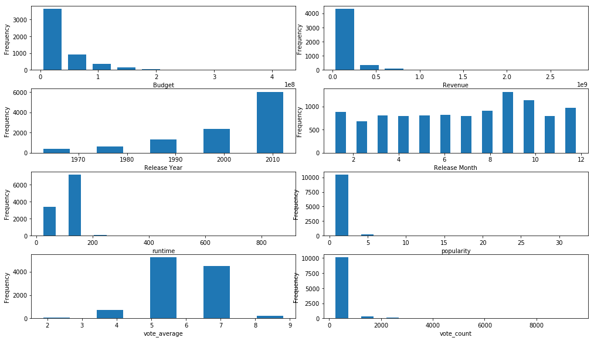

```python
#Plotting histogram for different variables
fig, ax = plt.subplots(4, 2, figsize=(14, 8))
fig.tight_layout()
df.budget_adj.plot.hist(ax=ax[0,0],rwidth=0.75)
df.revenue_adj.plot.hist(ax=ax[0,1],rwidth=0.75)
df.release_year.plot.hist(bins=5,ax=ax[1,0],rwidth=0.5)
df.release_month.plot.hist(bins=12,ax=ax[1,1],rwidth=0.5)
df.runtime.plot.hist(bins=10,ax=ax[2,0],rwidth=0.5)
df.popularity.plot.hist(ax=ax[2,1],rwidth=0.5)
df.vote_average.plot.hist(bins=5,ax=ax[3,0],rwidth=0.5)
df.vote_count.plot.hist(bins=10,ax=ax[3,1],rwidth=0.5)

ax[0][0].set_xlabel("Budget")
ax[0][1].set_xlabel("Revenue")
ax[1][0].set_xlabel("Release Year")
ax[1][1].set_xlabel("Release Month")
ax[2][0].set_xlabel("runtime")
ax[2][1].set_xlabel("popularity")
ax[3][0].set_xlabel("vote_average")
ax[3][1].set_xlabel("vote_count");
```

### Research Question 1:What features are associated with popular movies?

```python
df_popular=df.query('popularity>popularity.mean()')
df_popular.describe()
```

|  | id | popularity | runtime | vote_count | vote_average | release_year | budget_adj | revenue_adj | release_month |
| --- | --- | --- | --- | --- | --- | --- | --- | --- | --- |
| count | 3023.000000 | 3023.000000 | 3023.000000 | 3023.000000 | 3023.000000 | 3023.000000 | 2.475000e+03 | 2.510000e+03 | 3023.000000 |
| mean | 55864.132319 | 1.557925 | 107.845518 | 655.483626 | 6.255409 | 2003.026133 | 5.357789e+07 | 1.841036e+08 | 7.083030 |
| std | 85914.229144 | 1.540484 | 23.557236 | 943.603546 | 0.798126 | 11.221536 | 4.892928e+07 | 2.484731e+08 | 3.333948 |
| min | 5.000000 | 0.654013 | 3.000000 | 10.000000 | 3.300000 | 1960.000000 | 1.144773e+01 | 2.289547e+01 | 1.000000 |
| 25% | 4599.000000 | 0.826427 | 95.000000 | 146.000000 | 5.700000 | 1997.000000 | 1.842019e+07 | 3.666749e+07 | 4.000000 |
| 50% | 11374.000000 | 1.101383 | 105.000000 | 318.000000 | 6.300000 | 2006.000000 | 3.773675e+07 | 9.960355e+07 | 7.000000 |
| 75% | 68431.500000 | 1.691642 | 119.000000 | 728.500000 | 6.800000 | 2012.000000 | 7.414978e+07 | 2.282478e+08 | 10.000000 |
| max | 417859.000000 | 32.985763 | 540.000000 | 9767.000000 | 8.400000 | 2015.000000 | 3.683713e+08 | 2.827124e+09 | 12.000000 |

We can see that mean popularity for popular movies is 1.5,average runtime of 107 minutes,mean budget of $$ 53 million and mean revenue of $184 million.The average vote count is 655 and average rating around 6.25.

### Top 5 most popular movies all times

```python
df_top5=df_popular.sort_values('popularity',ascending=False).head()
df_top5
```

|  | id | popularity | original_title | cast | director | keywords | runtime | genres | production_companies | release_date | vote_count | vote_average | release_year | budget_adj | revenue_adj | release_month | budget_adj_levels | vote_average_levels | main_actor | main_keyword |
| --- | --- | --- | --- | --- | --- | --- | --- | --- | --- | --- | --- | --- | --- | --- | --- | --- | --- | --- | --- | --- |
| 0 | 135397 | 32.985763 | Jurassic World | Chris Pratt\|Bryce Dallas Howard\|Irrfan Khan\|Vi... | Colin Trevorrow | monster\|dna\|tyrannosaurus rex\|velociraptor\|island | 124 | Action\|Adventure\|Science Fiction\|Thriller | Universal Studios\|Amblin Entertainment\|Legenda... | 2015-06-09 | 5562 | 6.5 | 2015 | 1.379999e+08 | 1.392446e+09 | 6 | High | Moderately High | Chris Pratt | monster |
| 1 | 76341 | 28.419936 | Mad Max: Fury Road | Tom Hardy\|Charlize Theron\|Hugh Keays-Byrne\|Nic... | George Miller | future\|chase\|post-apocalyptic\|dystopia\|australia | 120 | Action\|Adventure\|Science Fiction\|Thriller | Village Roadshow Pictures\|Kennedy Miller Produ... | 2015-05-13 | 6185 | 7.1 | 2015 | 1.379999e+08 | 3.481613e+08 | 5 | High | High | Tom Hardy | future |
| 629 | 157336 | 24.949134 | Interstellar | Matthew McConaughey\|Jessica Chastain\|Anne Hath... | Christopher Nolan | saving the world\|artificial intelligence\|fathe... | 169 | Adventure\|Drama\|Science Fiction | Paramount Pictures\|Legendary Pictures\|Warner B... | 2014-11-05 | 6498 | 8.0 | 2014 | 1.519800e+08 | 5.726906e+08 | 11 | High | High | Matthew McConaughey | saving the world |
| 630 | 118340 | 14.311205 | Guardians of the Galaxy | Chris Pratt\|Zoe Saldana\|Dave Bautista\|Vin Dies... | James Gunn | marvel comic\|spaceship\|space\|scene during end ... | 121 | Action\|Science Fiction\|Adventure | Marvel Studios\|Moving Picture Company (MPC)\|Bu... | 2014-07-30 | 5612 | 7.9 | 2014 | 1.565855e+08 | 7.122911e+08 | 7 | High | High | Chris Pratt | marvel comic |
| 2 | 262500 | 13.112507 | Insurgent | Shailene Woodley\|Theo James\|Kate Winslet\|Ansel... | Robert Schwentke | based on novel\|revolution\|dystopia\|sequel\|dyst... | 119 | Adventure\|Science Fiction\|Thriller | Summit Entertainment\|Mandeville Films\|Red Wago... | 2015-03-18 | 2480 | 6.3 | 2015 | 1.012000e+08 | 2.716190e+08 | 3 | High | Moderately High | Shailene Woodley | based on novel |

### Data distribution for popular movies

```python
# bar plot for top 10 popular fields
def bar_plot_popular(column,title):
    fig = plt.subplots(figsize=(10, 3))
    ax=df_popular[column].value_counts()[:10].plot(kind='barh')
    ax.set_ylabel(column)
    ax.set_title('top')
    plt.title('Top 10 popular {} \n'.format(title), fontsize=18)
```

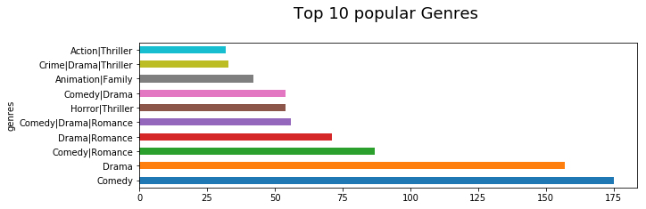

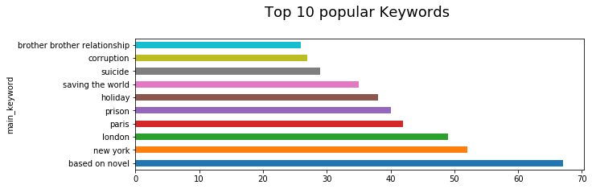

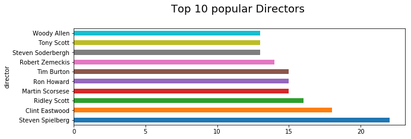

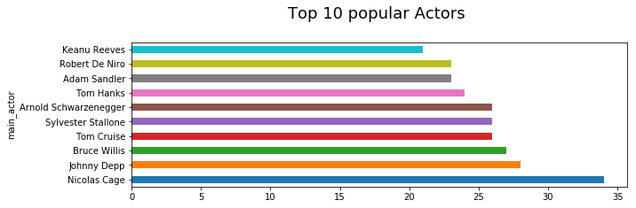

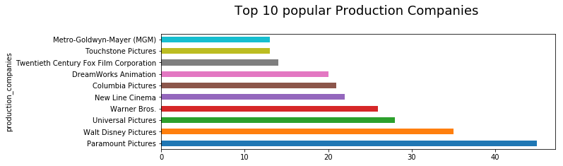

```python
bar_plot_popular('genres','Genres')
bar_plot_popular('main_keyword','Keywords')
bar_plot_popular('director','Directors')
bar_plot_popular('main_actor','Actors')
bar_plot_popular('production_companies','Production Companies')
```

#### Observations

- As we can see, the most prevalent popular film genre in our dataset is Comedy followed by Drama.
- Viewing the most popular keywords in this data, we can see that most popular movies seems to be based on novel.
- Most popular actors are Nicolas Cage and Johny Depp while popular directors are Steven Spielberg and Clint Eastwood
- The most popular production companies are Walt Disney ,Warner Bros., Universal Pictures, and Paramount Pictures producing highest number of popular movies.

### Features associated with unpopular movies

```python
df_unpopular=df.query('popularity<=popularity.mean()')
df_unpopular.describe()
```

|  | id | popularity | runtime | vote_count | vote_average | release_year | budget_adj | revenue_adj | release_month |
| --- | --- | --- | --- | --- | --- | --- | --- | --- | --- |
| count | 7680.000000 | 7680.000000 | 7680.000000 | 7680.000000 | 7680.000000 | 7680.000000 | 2.675000e+03 | 2.333000e+03 | 7680.000000 |
| mean | 68463.648177 | 0.297944 | 100.726042 | 49.049349 | 5.852240 | 2000.530469 | 2.169035e+07 | 4.113963e+07 | 6.735547 |
| std | 92910.969648 | 0.164948 | 32.066110 | 117.064228 | 0.953511 | 13.339775 | 2.628154e+07 | 7.179713e+07 | 3.466993 |
| min | 17.000000 | 0.000188 | 3.000000 | 10.000000 | 1.500000 | 1960.000000 | 9.210911e-01 | 2.370705e+00 | 1.000000 |
| 25% | 12266.500000 | 0.165375 | 90.000000 | 14.000000 | 5.300000 | 1993.000000 | 4.326677e+06 | 2.806994e+06 | 4.000000 |
| 50% | 24074.000000 | 0.280552 | 97.000000 | 24.000000 | 5.900000 | 2005.000000 | 1.262002e+07 | 1.798512e+07 | 7.000000 |
| 75% | 76116.750000 | 0.422553 | 108.000000 | 49.000000 | 6.500000 | 2011.000000 | 2.983419e+07 | 4.819724e+07 | 10.000000 |
| max | 414419.000000 | 0.653800 | 900.000000 | 4368.000000 | 9.200000 | 2015.000000 | 4.250000e+08 | 8.530813e+08 | 12.000000 |

### How does rating and runtime affect popularity?

#### Checking correlation between popularity,rating and runtime

```python
df[['popularity', 'vote_average','runtime']].corr()
```

|  | popularity | vote_average | runtime |
| --- | --- | --- | --- |
| popularity | 1.000000 | 0.217649 | 0.136339 |
| vote_average | 0.217649 | 1.000000 | 0.175063 |
| runtime | 0.136339 | 0.175063 | 1.000000 |

The small positive correlation between popularity,vote_average and runtime confirms my observation

### Top 10 unpoplar genres over the years

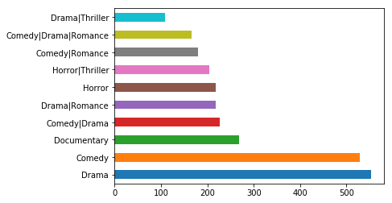

```python
df_unpopular['genres'].value_counts()[:10].plot(kind='barh');
```

### Top 5 least popular movies over the years

```python
df_unpopular.sort_values('popularity').head()
```

|  | id | popularity | original_title | cast | director | keywords | runtime | genres | production_companies | release_date | vote_count | vote_average | release_year | budget_adj | revenue_adj | release_month | budget_adj_levels | vote_average_levels | main_actor | main_keyword |
| --- | --- | --- | --- | --- | --- | --- | --- | --- | --- | --- | --- | --- | --- | --- | --- | --- | --- | --- | --- | --- |
| 9977 | 32082 | 0.000188 | The Hospital | George C. Scott\|Diana Rigg\|Richard Dysart\|Barn... | Arthur Hiller | hospital\|malpratice | 103 | Mystery\|Comedy\|Drama | Simcha Productions | 1971-12-14 | 10 | 6.4 | 1971 | NaN | NaN | 12 | NaN | Moderately High | George C. Scott | hospital |
| 6080 | 174323 | 0.000620 | G.B.F. | Michael J. Willett\|Paul Iacono\|Sasha Pieterse\|... | Darren Stein | gay\|gay kiss\|coming out\|high school\|friends | 92 | Comedy | School Pictures\|Parting Shots Media\|Logolite E... | 2013-10-20 | 82 | 6.1 | 2013 | NaN | NaN | 10 | NaN | Moderately High | Michael J. Willett | gay |
| 6551 | 31329 | 0.000973 | Mon petit doigt m'a dit... | Catherine Frot\|André Dussollier\|Geneviève Bu... | Pascal Thomas | NaN | 105 | Comedy\|Mystery | Rhône-Alpes Cinéma\|France2 Cinéma | 2005-04-13 | 13 | 5.7 | 2005 | NaN | NaN | 4 | NaN | Medium | Catherine Frot | NaN |
| 6961 | 15412 | 0.001115 | Khosla Ka Ghosla! | Anupam Kher\|Boman Irani\|Parvin Dabas\|Tara Shar... | Dibakar Banerjee | bollywood | 135 | Comedy | UTV Motion Pictures | 2006-09-22 | 10 | 6.8 | 2006 | NaN | NaN | 9 | NaN | High | Anupam Kher | bollywood |
| 7268 | 1392 | 0.001117 | Born into Brothels | Zana Briski\|Avijit\|Geeta Masi\|Kochi\|Mamuni | Zana Briski\|Ross Kauffman | prostitute\|red-light disctrict\|human trafficki... | 85 | Documentary | NaN | 2004-12-08 | 23 | 6.4 | 2004 | 404055.889934 | 4.057946e+06 | 12 | Low | Moderately High | Zana Briski | prostitute |

```python
df_drama=df[df['genres'].str.contains('Drama')]
```

```python
df_sf=df[df['genres'].str.contains('Science Fiction')]
```

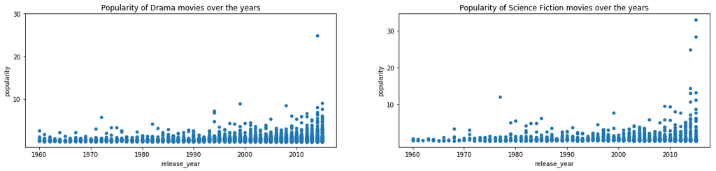

```python
fig, (ax1,ax2) = plt.subplots(1, 2, figsize=(20, 4))
df_drama.plot.scatter('release_year','popularity',ax=ax1)
df_sf.plot.scatter('release_year','popularity',ax=ax2)
ax1.yaxis.set_ticks([10,20,30])
ax1.set_title('Popularity of Drama movies over the years')
ax2.yaxis.set_ticks([ 10,20,30])
ax2.set_title('Popularity of Science Fiction movies over the years');
```

We can see significant increase in popularity in Science Fiction Movies over the years

### Research Question 2:How Budget affects popularity and ratings?

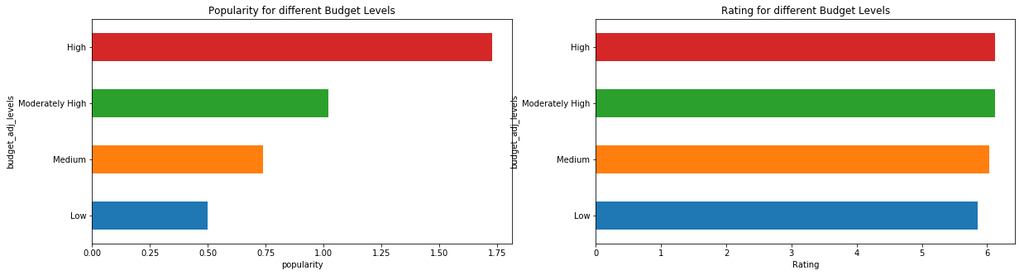

```python
fig, (ax1,ax2) = plt.subplots(1, 2, figsize=(20, 5))
df.groupby('budget_adj_levels').mean()['popularity'].plot(kind='barh',ax=ax1)
ax1.set_xlabel('popularity')
ax1.set_title('Popularity for different Budget Levels')
df.groupby('budget_adj_levels').mean()['vote_average'].plot(kind='barh',ax=ax2)
ax2.set_xlabel('Rating')
ax2.set_title('Rating for different Budget Levels');
```

#### Checking correlation between budget and rating

```python
df[['budget_adj', 'vote_average']].corr()
```

|  | budget_adj | vote_average |
| --- | --- | --- |
| budget_adj | 1.000000 | 0.112641 |
| vote_average | 0.112641 | 1.000000 |

#### Observations

We can see that higher the budget,more likely it is to be popular probably because of extensive marketing and advertising.However average rating for different budget levels are similiar which shows that ratings are unaffected by the movie budget

### Distribution of Popular Movies for different rating and budget levels

```python
def bar_plot_levels(column):
    fig = plt.subplots(figsize=(10, 3))
    ax=df_popular[column].value_counts().plot(kind='bar');
    ax.set_title(column)
```

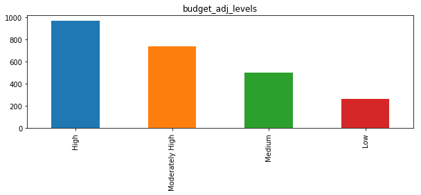

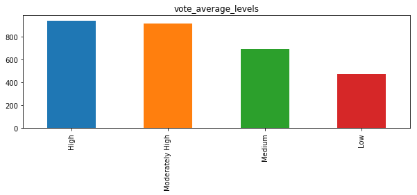

```python
bar_plot_levels('budget_adj_levels')
bar_plot_levels('vote_average_levels')
```

### Research Question 3:What are the most popular movies over the years(1960 to 2015)?

```python
df_pop_by_year=df.loc[df.groupby(['release_year'])['popularity'].idxmax()]
df_pop_by_year = df_pop_by_year.set_index(['release_year'])
df_pop_by_year
```

| release_year | id | popularity | original_title | cast | director | keywords | runtime | genres | production_companies | release_date | vote_count | vote_average | budget_adj | revenue_adj | release_month | budget_adj_levels | vote_average_levels | main_actor | main_keyword |
| --- | --- | --- | --- | --- | --- | --- | --- | --- | --- | --- | --- | --- | --- | --- | --- | --- | --- | --- | --- |
| 1960 | 539 | 2.610362 | Psycho | Anthony Perkins\|Vera Miles\|John Gavin\|Janet Le... | Alfred Hitchcock | hotel\|clerk\|arizona\|shower\|rain | 109 | Drama\|Horror\|Thriller | Shamley Productions | 2060-08-14 | 1180 | 8.0 | 5.949601e+06 | 2.359350e+08 | 8 | Low | High | Anthony Perkins | hotel |
| 1961 | 12230 | 2.631987 | One Hundred and One Dalmatians | Rod Taylor\|J. Pat O'Malley\|Betty Lou Gerson\|Ma... | Clyde Geronimi\|Hamilton Luske\|Wolfgang Reitherman | puppy\|animation\|dog\|dalmatian | 79 | Adventure\|Animation\|Comedy\|Family | Walt Disney Productions | 2061-01-25 | 913 | 6.6 | 2.917944e+07 | 1.574815e+09 | 1 | Moderately High | Moderately High | Rod Taylor | puppy |
| 1962 | 646 | 3.170651 | Dr. No | Sean Connery\|Ursula Andress\|Joseph Wiseman\|Jac... | Terence Young | london\|england\|assassination\|spy\|casino | 110 | Adventure\|Action\|Thriller | Eon Productions\|Metro-Goldwyn-Mayer (MGM) | 2062-10-04 | 560 | 6.7 | 7.929294e+06 | 4.296236e+08 | 10 | Low | High | Sean Connery | london |
| 1963 | 657 | 2.508235 | From Russia With Love | Sean Connery\|Daniela Bianchi\|Lotte Lenya\|Rober... | Terence Young | venice\|london\|terror\|england\|assassination | 115 | Action\|Thriller\|Adventure | Eon Productions\|Metro-Goldwyn-Mayer (MGM)\|Danjaq | 2063-10-11 | 458 | 6.7 | 1.780045e+07 | 5.617734e+08 | 10 | Medium | High | Sean Connery | venice |
| 1964 | 658 | 3.153791 | Goldfinger | Sean Connery\|Honor Blackman\|Gert Fröbe\|Shirle... | Guy Hamilton | secret organization\|secret intelligence servic... | 110 | Adventure\|Action\|Thriller | Eon Productions\|Metro-Goldwyn-Mayer (MGM) | 2064-09-17 | 602 | 7.0 | 2.460594e+07 | 8.780804e+08 | 9 | Moderately High | High | Sean Connery | secret organization |
| 1965 | 660 | 1.910465 | Thunderball | Sean Connery\|Claudine Auger\|Adolfo Celi\|Lucian... | Terence Young | paris\|florida\|fighter pilot\|sanatorium\|secret ... | 130 | Adventure\|Action\|Thriller | Eon Productions\|Metro-Goldwyn-Mayer (MGM) | 2065-12-16 | 331 | 6.3 | 7.612620e+07 | 9.771535e+08 | 12 | High | Moderately High | Sean Connery | paris |
| 1966 | 13377 | 1.227582 | How the Grinch Stole Christmas! | Boris Karloff\|June Foray\|Thurl Ravenscroft\|Dal... | Chuck Jones\|Ben Washam | holiday\|based on novel\|monster\|obsession\|santa... | 26 | Animation\|Family\|Comedy | MGM Television\|The Cat in the Hat Productions | 2066-12-18 | 286 | 7.1 | 2.116175e+06 | NaN | 12 | Low | High | Boris Karloff | holiday |
| 1967 | 9325 | 2.550704 | The Jungle Book | Phil Harris\|Sebastian Cabot\|Louis Prima\|George... | Wolfgang Reitherman | indian\|snake\|lion\|musical\|feral child | 78 | Family\|Animation\|Adventure | Walt Disney Pictures | 2067-10-18 | 928 | 7.0 | 2.614705e+07 | 1.345551e+09 | 10 | Moderately High | High | Phil Harris | indian |
| 1968 | 62 | 3.309196 | 2001: A Space Odyssey | Keir Dullea\|Douglas Rain\|Gary Lockwood\|William... | Stanley Kubrick | moon\|jupiter\|artificial intelligence\|man vs ma... | 149 | Science Fiction\|Mystery\|Adventure | Stanley Kubrick Productions\|Metro-Goldwyn-Maye... | 1968-04-05 | 1708 | 7.7 | 7.522756e+07 | 3.555466e+08 | 4 | High | High | Keir Dullea | moon |
| 1969 | 668 | 1.778746 | On Her Majesty's Secret Service | George Lazenby\|Diana Rigg\|Telly Savalas\|Gabrie... | Peter R. Hunt | london\|suicide\|england\|switzerland\|secret iden... | 142 | Adventure\|Action\|Thriller | Eon Productions\|Metro-Goldwyn-Mayer (MGM)\|Danjaq | 1969-12-12 | 258 | 6.4 | 4.160985e+07 | 4.872780e+08 | 12 | Moderately High | Moderately High | George Lazenby | london |
| 1970 | 10112 | 1.936962 | The Aristocats | Phil Harris\|Sterling Holloway\|Scatman Crothers... | Wolfgang Reitherman | paris\|cat\|butler\|return\|suspension | 78 | Animation\|Comedy\|Family\|Adventure | Walt Disney Productions | 1970-12-24 | 625 | 7.0 | 2.246547e+07 | 3.126928e+08 | 12 | Medium | High | Phil Harris | paris |
| 1971 | 185 | 3.072555 | A Clockwork Orange | Malcolm McDowell\|Patrick Magee\|Adrienne Corri\|... | Stanley Kubrick | prison\|street gang\|rape\|adolescence\|sexuality | 136 | Science Fiction\|Drama | Hawk Films\|Warner Bros. | 1971-12-18 | 1786 | 7.7 | 1.184743e+07 | 1.431869e+08 | 12 | Medium | High | Malcolm McDowell | prison |
| 1972 | 238 | 5.738034 | The Godfather | Marlon Brando\|Al Pacino\|James Caan\|Richard S. ... | Francis Ford Coppola | italy\|love at first sight\|loss of father\|patri... | 175 | Drama\|Crime | Paramount Pictures\|Alfran Productions | 1972-03-15 | 3970 | 8.3 | 3.128737e+07 | 1.277914e+09 | 3 | Moderately High | High | Marlon Brando | italy |
| 1973 | 11886 | 2.272486 | Robin Hood | Brian Bedford\|Phil Harris\|Peter Ustinov\|Pat Bu... | Wolfgang Reitherman | hero\|fox\|robin hood\|right and justice\|outlaw | 83 | Animation\|Family | Walt Disney Productions | 1973-11-08 | 641 | 6.9 | 7.366739e+07 | 1.574344e+08 | 11 | High | High | Brian Bedford | hero |
| 1974 | 240 | 3.264571 | The Godfather: Part II | Al Pacino\|Robert Duvall\|Diane Keaton\|Robert De... | Francis Ford Coppola | italo-american\|cuba\|vororte\|melancholy\|praise | 200 | Drama\|Crime | Paramount Pictures\|The Coppola Company | 1974-12-20 | 2131 | 8.1 | 5.748969e+07 | 2.102479e+08 | 12 | High | High | Al Pacino | italo-american |
| 1975 | 510 | 3.258151 | One Flew Over the Cuckoo's Nest | Jack Nicholson\|Louise Fletcher\|Danny DeVito\|Wi... | MiloÅ¡ Forman | individual\|rebel\|self-destruction\|wheelchair\|l... | 133 | Drama | Fantasy Films\|Warner Bros. | 1975-11-18 | 1612 | 8.0 | 1.215546e+07 | 4.415726e+08 | 11 | Medium | High | Jack Nicholson | individual |
| 1976 | 103 | 2.582657 | Taxi Driver | Robert De Niro\|Cybill Shepherd\|Harvey Keitel\|J... | Martin Scorsese | vietnam veteran\|taxi\|obsession\|drug dealer\|nig... | 113 | Crime\|Drama | Columbia Pictures Corporation\|Italo/Judeo Prod... | 1976-02-08 | 1269 | 7.8 | 4.981207e+06 | 1.082936e+08 | 2 | Low | High | Robert De Niro | vietnam veteran |
| 1977 | 11 | 12.037933 | Star Wars | Mark Hamill\|Harrison Ford\|Carrie Fisher\|Peter ... | George Lucas | android\|galaxy\|hermit\|death star\|lightsaber | 121 | Adventure\|Action\|Science Fiction | Lucasfilm\|Twentieth Century Fox Film Corporation | 1977-03-20 | 4428 | 7.9 | 3.957559e+07 | 2.789712e+09 | 3 | Moderately High | High | Mark Hamill | android |
| 1978 | 621 | 1.697618 | Grease | John Travolta\|Olivia Newton-John\|Stockard Chan... | Randal Kleiser | flying car\|street gang\|running\|graduation\|musical | 110 | Music | Paramount Pictures\|Robert Stigwood Organizatio... | 1978-07-07 | 786 | 7.0 | 2.005620e+07 | 6.077490e+08 | 7 | Medium | High | John Travolta | flying car |
| 1979 | 348 | 4.935897 | Alien | Sigourney Weaver\|Tom Skerritt\|Veronica Cartwri... | Ridley Scott | android\|self-destruction\|countdown\|space marin... | 117 | Horror\|Action\|Thriller\|Science Fiction | Twentieth Century-Fox Productions\|Brandywine P... | 1979-05-25 | 2724 | 7.6 | 3.305009e+07 | 3.152733e+08 | 5 | Moderately High | High | Sigourney Weaver | android |
| 1980 | 1891 | 5.488441 | The Empire Strikes Back | Mark Hamill\|Harrison Ford\|Carrie Fisher\|Billy ... | Irvin Kershner | rebel\|asteroid\|space battle\|snow storm\|space c... | 124 | Adventure\|Action\|Science Fiction | Lucasfilm\|Twentieth Century Fox Film Corporation | 1980-01-01 | 3954 | 8.0 | 4.762866e+07 | 1.424626e+09 | 1 | Moderately High | High | Mark Hamill | rebel |
| 1981 | 85 | 4.578300 | Raiders of the Lost Ark | Harrison Ford\|Karen Allen\|Paul Freeman\|Ronald ... | Steven Spielberg | saving the world\|riddle\|nepal\|himalaya\|cairo | 115 | Adventure\|Action | Lucasfilm\|Paramount Pictures | 1981-06-12 | 2506 | 7.5 | 4.316743e+07 | 9.351169e+08 | 6 | Moderately High | High | Harrison Ford | saving the world |
| 1982 | 78 | 4.215642 | Blade Runner | Harrison Ford\|Rutger Hauer\|Sean Young\|Edward J... | Ridley Scott | artificial intelligence\|man vs machine\|cyborg\|... | 117 | Science Fiction\|Drama\|Thriller | Shaw Brothers\|Warner Bros.\|The Ladd Company | 1982-06-25 | 2110 | 7.7 | 6.326999e+07 | 7.404548e+07 | 6 | High | High | Harrison Ford | artificial intelligence |
| 1983 | 1892 | 4.828854 | Return of the Jedi | Mark Hamill\|Harrison Ford\|Carrie Fisher\|Billy ... | Richard Marquand | rebel\|emperor\|space battle\|matter of life and ... | 135 | Adventure\|Action\|Science Fiction | Lucasfilm\|Twentieth Century Fox Film Corporation | 1983-05-23 | 3101 | 7.8 | 7.082424e+07 | 1.253819e+09 | 5 | High | High | Mark Hamill | rebel |
| 1984 | 218 | 4.831966 | The Terminator | Arnold Schwarzenegger\|Michael Biehn\|Linda Hami... | James Cameron | saving the world\|artificial intelligence\|rebel... | 108 | Action\|Thriller\|Science Fiction | Orion Pictures\|Pacific Western\|Hemdale Film\|Ci... | 1984-10-26 | 2692 | 7.1 | 1.343387e+07 | 1.645044e+08 | 10 | Medium | High | Arnold Schwarzenegger | saving the world |
| 1985 | 105 | 6.095293 | Back to the Future | Michael J. Fox\|Christopher Lloyd\|Lea Thompson\|... | Robert Zemeckis | clock tower\|car race\|terrorist\|delorean\|lightning | 116 | Adventure\|Comedy\|Science Fiction\|Family | Universal Pictures\|Amblin Entertainment\|U-Driv... | 1985-07-03 | 3785 | 7.8 | 3.851615e+07 | 7.725728e+08 | 7 | Moderately High | High | Michael J. Fox | clock tower |
| 1986 | 679 | 2.485419 | Aliens | Sigourney Weaver\|Carrie Henn\|Michael Biehn\|Lan... | James Cameron | android\|extraterrestrial technology\|space mari... | 137 | Horror\|Action\|Thriller\|Science Fiction | Twentieth Century Fox Film Corporation\|SLM Pro... | 1986-07-18 | 2027 | 7.6 | 3.680402e+07 | 2.607321e+08 | 7 | Moderately High | High | Sigourney Weaver | android |
| 1987 | 106 | 3.474728 | Predator | Arnold Schwarzenegger\|Carl Weathers\|Elpidia Ca... | John McTiernan | central and south america\|predator\|alien\|stalk... | 107 | Science Fiction\|Action\|Adventure\|Thriller | Twentieth Century Fox Film Corporation\|Lawrenc... | 1987-06-11 | 1250 | 7.1 | 3.454345e+07 | 1.885219e+08 | 6 | Moderately High | High | Arnold Schwarzenegger | central and south america |
| 1988 | 562 | 3.777441 | Die Hard | Bruce Willis\|Alan Rickman\|Alexander Godunov\|Bo... | John McTiernan | helicopter\|journalist\|based on novel\|terrorist... | 131 | Action\|Thriller | Twentieth Century Fox Film Corporation\|Gordon ... | 1988-07-15 | 2800 | 7.2 | 5.162895e+07 | 2.595608e+08 | 7 | High | High | Bruce Willis | helicopter |
| 1989 | 10144 | 4.143585 | The Little Mermaid | Jodi Benson\|Christopher Daniel Barnes\|Jason Ma... | Ron Clements\|John Musker | sea\|fireworks\|prince\|kingdom\|daughter | 83 | Animation\|Family | Walt Disney Pictures | 1989-11-17 | 1042 | 7.1 | 7.035940e+07 | 3.717500e+08 | 11 | High | High | Jodi Benson | sea |
| 1990 | 861 | 2.679627 | Total Recall | Arnold Schwarzenegger\|Sharon Stone\|Rachel Tico... | Paul Verhoeven | oxygen\|falsely accused person\|resistance\|mars\|... | 113 | Action\|Adventure\|Science Fiction | TriStar Pictures\|Carolco Pictures\|Carolco Inte... | 1990-06-01 | 1012 | 6.8 | 1.084784e+08 | 4.361131e+08 | 6 | High | High | Arnold Schwarzenegger | oxygen |
| 1991 | 10020 | 3.852269 | Beauty and the Beast | Paige O'Hara\|Robby Benson\|Richard White\|Jerry ... | Gary Trousdale\|Kirk Wise | prince\|book\|castle\|rose\|musical | 84 | Romance\|Family\|Animation\|Fantasy\|Music | Walt Disney Pictures\|Walt Disney Animation Stu... | 1991-11-12 | 1703 | 7.3 | 4.002732e+07 | 6.041733e+08 | 11 | Moderately High | High | Paige O'Hara | prince |
| 1992 | 500 | 4.586426 | Reservoir Dogs | Harvey Keitel\|Tim Roth\|Michael Madsen\|Chris Pe... | Quentin Tarantino | torture\|gasoline\|shot in the stomach\|sadistic ... | 99 | Crime\|Thriller | Live Entertainment\|Lionsgate\|Dog Eat Dog Produ... | 1992-06-25 | 2018 | 7.9 | 1.864829e+06 | 2.278356e+07 | 6 | Low | High | Harvey Keitel | torture |
| 1993 | 137 | 2.571339 | Groundhog Day | Bill Murray\|Andie MacDowell\|Chris Elliott\|Step... | Harold Ramis | deja vu\|groundhog\|weather forecast\|telecaster\|... | 101 | Romance\|Fantasy\|Drama\|Comedy | Columbia Pictures | 1993-02-11 | 1339 | 7.2 | 2.203826e+07 | 1.070319e+08 | 2 | Medium | High | Bill Murray | deja vu |
| 1994 | 680 | 8.093754 | Pulp Fiction | John Travolta\|Samuel L. Jackson\|Uma Thurman\|Br... | Quentin Tarantino | transporter\|brothel\|drug dealer\|boxer\|massage | 154 | Thriller\|Crime | Miramax Films\|A Band Apart\|Jersey Films | 1994-10-14 | 5343 | 8.1 | 1.176889e+07 | 3.147131e+08 | 10 | Medium | High | John Travolta | transporter |
| 1995 | 807 | 4.765359 | Se7en | Brad Pitt\|Morgan Freeman\|Gwyneth Paltrow\|John ... | David Fincher | self-fulfilling prophecy\|detective\|s.w.a.t.\|dr... | 127 | Crime\|Mystery\|Thriller | New Line Cinema\|Juno Pix\|Cecchi Gori Pictures | 1995-09-22 | 3535 | 7.9 | 4.722191e+07 | 4.683724e+08 | 9 | Moderately High | High | Brad Pitt | self-fulfilling prophecy |
| 1996 | 602 | 4.480733 | Independence Day | Will Smith\|Bill Pullman\|Jeff Goldblum\|Mary McD... | Roland Emmerich | spacecraft\|patriotism\|countdown\|invasion\|indep... | 145 | Action\|Adventure\|Science Fiction | Twentieth Century Fox Film Corporation\|Centrop... | 1996-06-25 | 2000 | 6.6 | 1.042663e+08 | 1.135764e+09 | 6 | High | Moderately High | Will Smith | spacecraft |
| 1997 | 13590 | 6.668990 | Eddie Izzard: Glorious | Eddie Izzard\|Mac McDonald\|Rhona Mitra | Peter Richardson | bible\|stand up comedy\|concert film\|old testame... | 99 | Comedy | NaN | 1997-11-17 | 11 | 5.5 | NaN | NaN | 11 | NaN | Medium | Eddie Izzard | bible |
| 1998 | 37165 | 4.180540 | The Truman Show | Jim Carrey\|Laura Linney\|Noah Emmerich\|Natascha... | Peter Weir | claustrophobia\|hidden camera\|dystopia\|reality ... | 103 | Comedy\|Drama | Paramount Pictures\|Scott Rudin Productions | 1998-06-04 | 2392 | 7.6 | 8.026173e+07 | 3.533097e+08 | 6 | High | High | Jim Carrey | claustrophobia |
| 1999 | 550 | 8.947905 | Fight Club | Edward Norton\|Brad Pitt\|Meat Loaf\|Jared Leto\|H... | David Fincher | support group\|dual identity\|nihilism\|rage and ... | 139 | Drama | Regency Enterprises\|Fox 2000 Pictures\|Taurus F... | 1999-10-14 | 5923 | 8.1 | 8.247033e+07 | 1.320229e+08 | 10 | High | High | Edward Norton | support group |
| 2000 | 98 | 4.271452 | Gladiator | Russell Crowe\|Joaquin Phoenix\|Connie Nielsen\|O... | Ridley Scott | rome\|gladiator\|roman empire\|slavery\|battlefield | 155 | Action\|Drama\|Adventure | DreamWorks SKG\|Universal Pictures\|Scott Free P... | 2000-05-01 | 3531 | 7.7 | 1.304281e+08 | 5.795065e+08 | 5 | High | High | Russell Crowe | rome |
| 2001 | 120 | 8.575419 | The Lord of the Rings: The Fellowship of the Ring | Elijah Wood\|Ian McKellen\|Viggo Mortensen\|Liv T... | Peter Jackson | elves\|dwarves\|orcs\|middle-earth (tolkien)\|hobbits | 178 | Adventure\|Fantasy\|Action | WingNut Films\|New Line Cinema\|The Saul Zaentz ... | 2001-12-18 | 6079 | 7.8 | 1.145284e+08 | 1.073080e+09 | 12 | High | High | Elijah Wood | elves |
| 2002 | 121 | 8.095275 | The Lord of the Rings: The Two Towers | Elijah Wood\|Ian McKellen\|Viggo Mortensen\|Liv T... | Peter Jackson | elves\|orcs\|middle-earth (tolkien)\|hobbits\|base... | 179 | Adventure\|Fantasy\|Action | WingNut Films\|New Line Cinema\|The Saul Zaentz ... | 2002-12-18 | 5114 | 7.8 | 9.576865e+07 | 1.122902e+09 | 12 | High | High | Elijah Wood | elves |
| 2003 | 122 | 7.122455 | The Lord of the Rings: The Return of the King | Elijah Wood\|Ian McKellen\|Viggo Mortensen\|Liv T... | Peter Jackson | elves\|orcs\|middle-earth (tolkien)\|based on nov... | 201 | Adventure\|Fantasy\|Action | WingNut Films\|New Line Cinema | 2003-12-01 | 5636 | 7.9 | 1.114231e+08 | 1.326278e+09 | 12 | High | High | Elijah Wood | elves |
| 2004 | 673 | 5.827781 | Harry Potter and the Prisoner of Azkaban | Daniel Radcliffe\|Rupert Grint\|Emma Watson\|Gary... | Alfonso Cuarón | flying\|traitor\|cutting the cord\|child hero\|broom | 141 | Adventure\|Fantasy\|Family | 1492 Pictures\|Warner Bros.\|Heyday Films\|P of A... | 2004-05-31 | 3550 | 7.4 | 1.500779e+08 | 9.117862e+08 | 5 | High | High | Daniel Radcliffe | flying |
| 2005 | 674 | 5.939927 | Harry Potter and the Goblet of Fire | Daniel Radcliffe\|Rupert Grint\|Emma Watson\|Ralp... | Mike Newell | diving\|library\|flying\|fireworks\|cutting the cord | 157 | Adventure\|Fantasy\|Family | Patalex IV Productions Limited\|Warner Bros.\|He... | 2005-11-05 | 3406 | 7.3 | 1.674845e+08 | 1.000353e+09 | 11 | High | High | Daniel Radcliffe | diving |
| 2006 | 834 | 5.838503 | Underworld: Evolution | Kate Beckinsale\|Scott Speedman\|Tony Curran\|Sha... | Len Wiseman | budapest\|key\|light\|werewolf\|evolution | 106 | Fantasy\|Action\|Science Fiction\|Thriller | Lakeshore Entertainment\|Screen Gems | 2006-01-12 | 1015 | 6.3 | 5.408346e+07 | 1.204339e+08 | 1 | High | Moderately High | Kate Beckinsale | budapest |
| 2007 | 285 | 4.965391 | Pirates of the Caribbean: At World's End | Johnny Depp\|Orlando Bloom\|Keira Knightley\|Geof... | Gore Verbinski | ocean\|drug abuse\|exotic island\|east india trad... | 169 | Adventure\|Fantasy\|Action | Walt Disney Pictures\|Jerry Bruckheimer Films\|S... | 2007-05-19 | 2626 | 6.8 | 3.155006e+08 | 1.010654e+09 | 5 | High | High | Johnny Depp | ocean |
| 2008 | 155 | 8.466668 | The Dark Knight | Christian Bale\|Michael Caine\|Heath Ledger\|Aaro... | Christopher Nolan | dc comics\|crime fighter\|secret identity\|scarec... | 152 | Drama\|Action\|Crime\|Thriller | DC Comics\|Legendary Pictures\|Warner Bros.\|Syncopy | 2008-07-16 | 8432 | 8.1 | 1.873655e+08 | 1.014733e+09 | 7 | High | High | Christian Bale | dc comics |
| 2009 | 19995 | 9.432768 | Avatar | Sam Worthington\|Zoe Saldana\|Sigourney Weaver\|S... | James Cameron | culture clash\|future\|space war\|space colony\|so... | 162 | Action\|Adventure\|Fantasy\|Science Fiction | Ingenious Film Partners\|Twentieth Century Fox ... | 2009-12-10 | 8458 | 7.1 | 2.408869e+08 | 2.827124e+09 | 12 | High | High | Sam Worthington | culture clash |
| 2010 | 27205 | 9.363643 | Inception | Leonardo DiCaprio\|Joseph Gordon-Levitt\|Ellen P... | Christopher Nolan | loss of lover\|dream\|sleep\|subconsciousness\|heist | 148 | Action\|Thriller\|Science Fiction\|Mystery\|Adventure | Legendary Pictures\|Warner Bros.\|Syncopy | 2010-07-14 | 9767 | 7.9 | 1.600000e+08 | 8.255000e+08 | 7 | High | High | Leonardo DiCaprio | loss of lover |
| 2011 | 161337 | 8.411577 | Underworld: Endless War | Trevor Devall\|Brian Dobson\|Paul Dobson\|Laura H... | Juno John Lee | paris\|france\|vampire\|night\|woman with gun | 18 | Action\|Animation\|Horror | NaN | 2011-10-19 | 21 | 5.9 | NaN | NaN | 10 | NaN | Medium | Trevor Devall | paris |
| 2012 | 24428 | 7.637767 | The Avengers | Robert Downey Jr.\|Chris Evans\|Mark Ruffalo\|Chr... | Joss Whedon | new york\|shield\|marvel comic\|comic\|superhero | 143 | Science Fiction\|Action\|Adventure | Marvel Studios | 2012-04-25 | 8903 | 7.3 | 2.089437e+08 | 1.443191e+09 | 4 | High | High | Robert Downey Jr. | new york |
| 2013 | 109445 | 6.112766 | Frozen | Kristen Bell\|Idina Menzel\|Jonathan Groff\|Josh ... | Chris Buck\|Jennifer Lee | queen\|musical\|princess\|betrayal\|snowman | 102 | Animation\|Adventure\|Family | Walt Disney Pictures\|Walt Disney Animation Stu... | 2013-11-27 | 3369 | 7.5 | 1.404050e+08 | 1.192711e+09 | 11 | High | High | Kristen Bell | queen |
| 2014 | 157336 | 24.949134 | Interstellar | Matthew McConaughey\|Jessica Chastain\|Anne Hath... | Christopher Nolan | saving the world\|artificial intelligence\|fathe... | 169 | Adventure\|Drama\|Science Fiction | Paramount Pictures\|Legendary Pictures\|Warner B... | 2014-11-05 | 6498 | 8.0 | 1.519800e+08 | 5.726906e+08 | 11 | High | High | Matthew McConaughey | saving the world |
| 2015 | 135397 | 32.985763 | Jurassic World | Chris Pratt\|Bryce Dallas Howard\|Irrfan Khan\|Vi... | Colin Trevorrow | monster\|dna\|tyrannosaurus rex\|velociraptor\|island | 124 | Action\|Adventure\|Science Fiction\|Thriller | Universal Studios\|Amblin Entertainment\|Legenda... | 2015-06-09 | 5562 | 6.5 | 1.379999e+08 | 1.392446e+09 | 6 | High | Moderately High | Chris Pratt | monster |

```python
#Drop rows with null values for better visualization
df_pop_by_year.dropna(inplace=True)
```

### Line plot of different Movie metrics for popular movies over the years

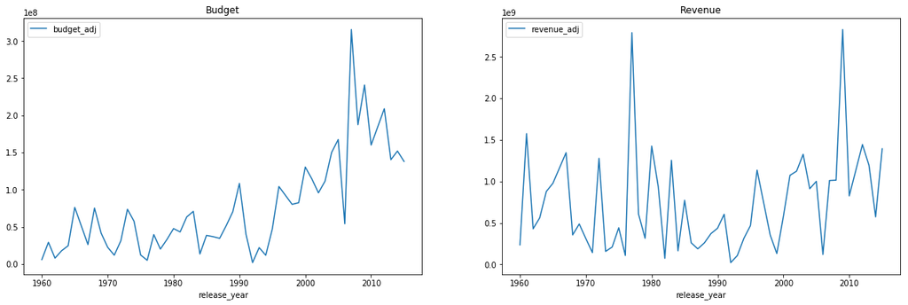

```python
fig, (ax1,ax2) = plt.subplots(1, 2, figsize=(20, 6))
df_pop_by_year['budget_adj'].plot(ax=ax1,legend=True,title='Budget')
df_pop_by_year['revenue_adj'].plot(ax=ax2,legend=True,title='Revenue');
```

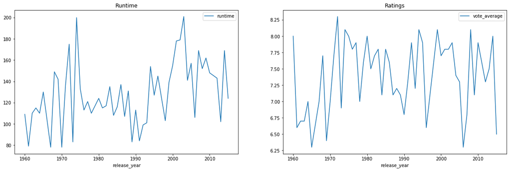

```python
fig, (ax1,ax2) = plt.subplots(1, 2, figsize=(20, 6))
df_pop_by_year['runtime'].plot(ax=ax1,legend=True,title='Runtime')
df_pop_by_year['vote_average'].plot(ax=ax2,legend=True,title='Ratings');
```

### Research Question 4:What properties are associated with successful movies?

### Top 10 high grossing movies of all times

```python
df_top10=df.sort_values('revenue_adj',ascending=False).head(10)
df_top10
```

|  | id | popularity | original_title | cast | director | keywords | runtime | genres | production_companies | release_date | vote_count | vote_average | release_year | budget_adj | revenue_adj | release_month | budget_adj_levels | vote_average_levels | main_actor | main_keyword |
| --- | --- | --- | --- | --- | --- | --- | --- | --- | --- | --- | --- | --- | --- | --- | --- | --- | --- | --- | --- | --- |
| 1386 | 19995 | 9.432768 | Avatar | Sam Worthington\|Zoe Saldana\|Sigourney Weaver\|S... | James Cameron | culture clash\|future\|space war\|space colony\|so... | 162 | Action\|Adventure\|Fantasy\|Science Fiction | Ingenious Film Partners\|Twentieth Century Fox ... | 2009-12-10 | 8458 | 7.1 | 2009 | 2.408869e+08 | 2.827124e+09 | 12 | High | High | Sam Worthington | culture clash |
| 1329 | 11 | 12.037933 | Star Wars | Mark Hamill\|Harrison Ford\|Carrie Fisher\|Peter ... | George Lucas | android\|galaxy\|hermit\|death star\|lightsaber | 121 | Adventure\|Action\|Science Fiction | Lucasfilm\|Twentieth Century Fox Film Corporation | 1977-03-20 | 4428 | 7.9 | 1977 | 3.957559e+07 | 2.789712e+09 | 3 | Moderately High | High | Mark Hamill | android |
| 5231 | 597 | 4.355219 | Titanic | Kate Winslet\|Leonardo DiCaprio\|Frances Fisher\|... | James Cameron | shipwreck\|iceberg\|ship\|panic\|titanic | 194 | Drama\|Romance\|Thriller | Paramount Pictures\|Twentieth Century Fox Film ... | 1997-11-18 | 4654 | 7.3 | 1997 | 2.716921e+08 | 2.506406e+09 | 11 | High | High | Kate Winslet | shipwreck |
| 10594 | 9552 | 2.010733 | The Exorcist | Linda Blair\|Max von Sydow\|Ellen Burstyn\|Jason ... | William Friedkin | exorcism\|holy water\|religion and supernatural\|... | 122 | Drama\|Horror\|Thriller | Warner Bros.\|Hoya Productions | 1973-12-26 | 1113 | 7.2 | 1973 | 3.928928e+07 | 2.167325e+09 | 12 | Moderately High | High | Linda Blair | exorcism |
| 9806 | 578 | 2.563191 | Jaws | Roy Scheider\|Robert Shaw\|Richard Dreyfuss\|Lorr... | Steven Spielberg | fishing\|atlantic ocean\|bathing\|shipwreck\|polic... | 124 | Horror\|Thriller\|Adventure | Universal Pictures\|Zanuck/Brown Productions | 1975-06-18 | 1415 | 7.3 | 1975 | 2.836275e+07 | 1.907006e+09 | 6 | Moderately High | High | Roy Scheider | fishing |
| 3 | 140607 | 11.173104 | Star Wars: The Force Awakens | Harrison Ford\|Mark Hamill\|Carrie Fisher\|Adam D... | J.J. Abrams | android\|spaceship\|jedi\|space opera\|3d | 136 | Action\|Adventure\|Science Fiction\|Fantasy | Lucasfilm\|Truenorth Productions\|Bad Robot | 2015-12-15 | 5292 | 7.5 | 2015 | 1.839999e+08 | 1.902723e+09 | 12 | High | High | Harrison Ford | android |
| 8889 | 601 | 2.900556 | E.T. the Extra-Terrestrial | Henry Thomas\|Drew Barrymore\|Robert MacNaughton... | Steven Spielberg | farewell\|homesickness\|nasa\|extraterrestrial te... | 115 | Science Fiction\|Adventure\|Family\|Fantasy | Universal Pictures\|Amblin Entertainment | 1982-04-03 | 1830 | 7.2 | 1982 | 2.372625e+07 | 1.791694e+09 | 4 | Moderately High | High | Henry Thomas | farewell |
| 8094 | 1642 | 1.136610 | The Net | Sandra Bullock\|Jeremy Northam\|Dennis Miller\|We... | Irwin Winkler | cheating\|new identity\|computer virus\|chase\|com... | 114 | Crime\|Drama\|Mystery\|Thriller\|Action | Columbia Pictures | 1995-07-28 | 201 | 5.6 | 1995 | 3.148127e+07 | 1.583050e+09 | 7 | Moderately High | Medium | Sandra Bullock | cheating |
| 10110 | 12230 | 2.631987 | One Hundred and One Dalmatians | Rod Taylor\|J. Pat O'Malley\|Betty Lou Gerson\|Ma... | Clyde Geronimi\|Hamilton Luske\|Wolfgang Reitherman | puppy\|animation\|dog\|dalmatian | 79 | Adventure\|Animation\|Comedy\|Family | Walt Disney Productions | 2061-01-25 | 913 | 6.6 | 1961 | 2.917944e+07 | 1.574815e+09 | 1 | Moderately High | Moderately High | Rod Taylor | puppy |
| 4361 | 24428 | 7.637767 | The Avengers | Robert Downey Jr.\|Chris Evans\|Mark Ruffalo\|Chr... | Joss Whedon | new york\|shield\|marvel comic\|comic\|superhero | 143 | Science Fiction\|Action\|Adventure | Marvel Studios | 2012-04-25 | 8903 | 7.3 | 2012 | 2.089437e+08 | 1.443191e+09 | 4 | High | High | Robert Downey Jr. | new york |

### Revenue associated with top 10 high grossing movies

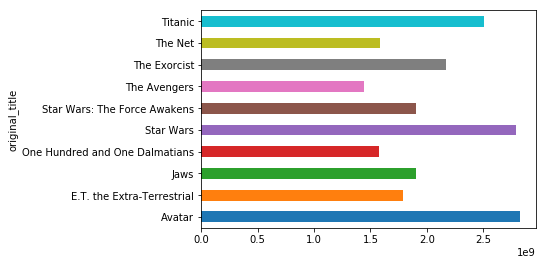

```python
df_top10.groupby('original_title')['revenue_adj'].mean().plot(kind='barh');
```

### Budget associated with top 10 high grossing movies

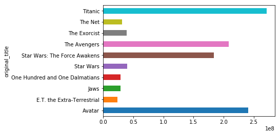

```python
df_top10.groupby('original_title').mean()['budget_adj'].plot(kind='barh');
```

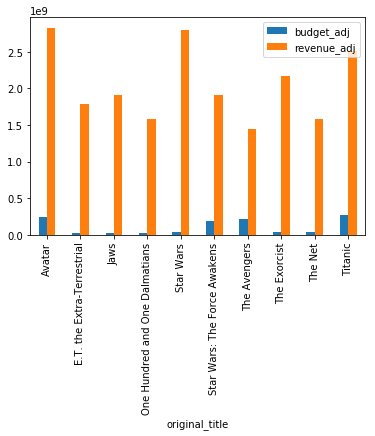

```python
df_top10[['original_title','budget_adj','revenue_adj']].groupby('original_title').mean().plot(kind='bar');
```

As we can see, all of these filmed have garnered over $1 billion revenue, with 'Avatar' being the highest grossing movie.

### Factors affecting Revenue

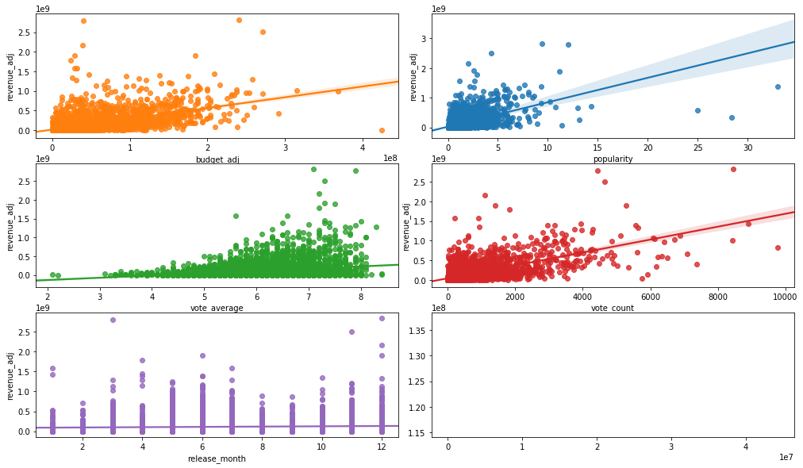

```python
fig, ax = plt.subplots(3, 2, figsize=(14, 8))
fig.tight_layout()
sns.regplot(data=df, x='popularity', y='revenue_adj',ax=ax[0][1])
sns.regplot(data=df, x='budget_adj', y='revenue_adj',ax=ax[0][0])
sns.regplot(data=df, x='vote_average', y='revenue_adj',ax=ax[1][0])
sns.regplot(data=df, x='vote_count', y='revenue_adj',ax=ax[1][1])
sns.regplot(data=df, x='release_month', y='revenue_adj',ax=ax[2][0]);
```

## Conclusions

The following relationships were found

#### Exploring the original questions conceived for the dataset:

- What features are associated with popular movies?

  Drama and Comedy has been most popular genres mostly because these are the most common genres produced.The movies with highest popularity score are all recent releases with genre being Adventure and Science fiction.
- How budget affects popularity and ratings?

  We have seen that most of the popular movies also have high budget probably because of better marketing,better cast and directors. However ratings are unafected by budget.
- What properties are associated with successful movies?

  High grossing movies typically have higher budge, popularity score and vote count.Avatar,Star wars and Titanic have been most successful movies of all times.

#### Limitations

- Most of the data available are for movies released after 1990.Hence for movies released prior to 1990 relationship between metrices may not be accurate.
- Since more than half of the data is missing budget and revenue information, final results may not accurately depict trend of successful movies over the years.
- The budget and revenue columns do not have currency unit.For my analysis I have assumed the currency to be in US dollars.However it might be possible some of the movies in the data have budget in different currency.This may have also impacted the overall analysis.
- Looking at the correlation between the variables,we may say that they are related but it doesnt imply causation.Further research may be needed investigating whether one action caused the other.